# Titanic-data Analysis

We have to investigate the 891 data set which is provided . The dataset consists of 891 passenger who boarded the titanic from differnet Embarked station . You might be curious to know what factors made the people more likely to survive than others. 1)Which class people were most probable to be saved 2)which age group has the most probability to be saved 3)Which gender had the most probability to be saved. I have delt with all these questions including the age distribution intially and much more.

First, we need to get the data set which is available as the csv file

```python
#importing the pandas and the numPy

import pandas as pd
import numpy as np

titanic_data = pd.read_csv('titanic-data.csv') #reading the csv file
```

Here,we investigate the data ,to check whether there is any duplication of data or how many values of each filed is empty

```python
print(len(titanic_data['PassengerId'].unique()))#investing the data
print(len(titanic_data['PassengerId']))
titanic_data.info() #here we notice that some fields have no value like age has only 714 but it should have been 891
```

```
891
891
<class 'pandas.core.frame.DataFrame'>
RangeIndex: 891 entries, 0 to 890
Data columns (total 12 columns):
PassengerId    891 non-null int64
Survived       891 non-null int64
Pclass         891 non-null int64
Name           891 non-null object
Sex            891 non-null object
Age            714 non-null float64
SibSp          891 non-null int64
Parch          891 non-null int64
Ticket         891 non-null object
Fare           891 non-null float64
Cabin          204 non-null object
Embarked       889 non-null object
dtypes: float64(2), int64(5), object(5)
memory usage: 83.6+ KB
```

Now, from the above investigation we know that few values are empty,we'll try to get the exact number.

```python
titanic_data.isnull().sum() #here we made sure about the number of fields which are empty
```

```
PassengerId      0
Survived         0
Pclass           0
Name             0
Sex              0
Age            177
SibSp            0
Parch            0
Ticket           0
Fare             0
Cabin          687
Embarked         2
dtype: int64
```

Here ,we have many missing values such as age has 177 missing values, but the point to notice is that we are plotting the data on the graph and matplotlib implicitely removes all the missing values and performs the task on the data which is available. For example,

```python
print(titanic_data['Age'].mean())
print(titanic_data['Age'].sum()/714)
```

```
29.6991176471
29.6991176471
```

The above example makes it clear that the mean() function is taking the mean of the values which is provided and the empty values are not affecting it.

For comparing the onboard and survived passenger we need to group them up on basis of filed which is of your interest. Here I have defined the function for the same and called the same for getting the data.

```python
def intial_survived(column): # defing the function to get the statistical data
    #getting the total number of saved indiviuals grouped by the passing column who survived
    survival_column = titanic_data.groupby(column)['Survived'].sum()
    # to get the total number of people wo were intially onboard
    total_column = titanic_data.groupby(column).size()
    # to concat the two data
    statistic_data = pd.concat([total_column,survival_column],axis=1)
    # to rename the column of the concatted dataset
    statistic_data = statistic_data.rename(columns = {0:'Intially'})
    #to find the portion of people saved
    statistic_data['portion_saved'] = survival_column / total_column
    # to find the probability of people saved
    statistic_data['probability_saved'] = statistic_data.portion_saved / statistic_data['portion_saved'].sum()

    return statistic_data
```

```python
statistic_age = intial_survived('Age') # calling the function by sending the column
statistic_gender = intial_survived('Sex')
statistic_embarked = intial_survived('Embarked')
statistic_class = intial_survived('Pclass')
print(statistic_age)  #printing the statistical data we got
print(statistic_class)
print(statistic_gender)
print(statistic_embarked)
```

```
       Intially  Survived  portion_saved  probability_saved
Age
0.42          1         1       1.000000           0.028923
0.67          1         1       1.000000           0.028923
0.75          2         2       1.000000           0.028923
0.83          2         2       1.000000           0.028923
0.92          1         1       1.000000           0.028923
1.00          7         5       0.714286           0.020659
2.00         10         3       0.300000           0.008677
3.00          6         5       0.833333           0.024103
4.00         10         7       0.700000           0.020246
5.00          4         4       1.000000           0.028923
6.00          3         2       0.666667           0.019282
7.00          3         1       0.333333           0.009641
8.00          4         2       0.500000           0.014462
9.00          8         2       0.250000           0.007231
10.00         2         0       0.000000           0.000000
11.00         4         1       0.250000           0.007231
12.00         1         1       1.000000           0.028923
13.00         2         2       1.000000           0.028923
14.00         6         3       0.500000           0.014462
14.50         1         0       0.000000           0.000000
15.00         5         4       0.800000           0.023139
16.00        17         6       0.352941           0.010208
17.00        13         6       0.461538           0.013349
18.00        26         9       0.346154           0.010012
19.00        25         9       0.360000           0.010412
20.00        15         3       0.200000           0.005785
20.50         1         0       0.000000           0.000000
21.00        24         5       0.208333           0.006026
22.00        27        11       0.407407           0.011784
23.00        15         5       0.333333           0.009641
...         ...       ...            ...                ...
44.00         9         3       0.333333           0.009641
45.00        12         5       0.416667           0.012051
45.50         2         0       0.000000           0.000000
46.00         3         0       0.000000           0.000000
47.00         9         1       0.111111           0.003214
48.00         9         6       0.666667           0.019282
49.00         6         4       0.666667           0.019282
```

[output cut: 24 more lines]

```
[88 rows x 4 columns]
        Intially  Survived  portion_saved  probability_saved
Pclass
1            216       136       0.629630           0.468189
2            184        87       0.472826           0.351591
3            491       119       0.242363           0.180220
        Intially  Survived  portion_saved  probability_saved
Sex
female       314       233       0.742038           0.797079
male         577       109       0.188908           0.202921
          Intially  Survived  portion_saved  probability_saved
Embarked
C              168        93       0.553571           0.432431
Q               77        30       0.389610           0.304350
S              644       217       0.336957           0.263219
```

As we have all the grouped data, we have all the armour for plotting the graphs. I felt the pie plot would be the best to describe the data.

```python
#importing all the important libraries for visualization of data
%pylab inline
import matplotlib
import seaborn as sns
```

[output not shown]

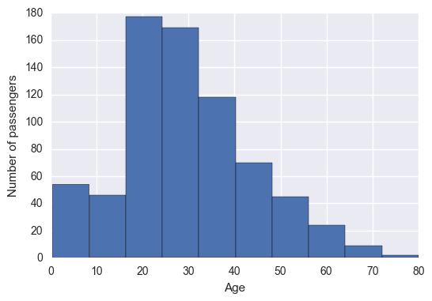

```python
a = titanic_data['Age'].hist()
a.set_xlabel("Age")
a.set_ylabel("Number of passengers")
```

The age distribution of people who boarded the titanic is demonstrated above

```python
# Ploting the  function for a pie plot
def pie_plot(values,explode,labels,colors):
    plt.pie(values, explode=explode, labels=labels, colors=colors,
            autopct='%1.1f%%', shadow=True, startangle=180)

    plt.axis('equal')
    plt.show()
```

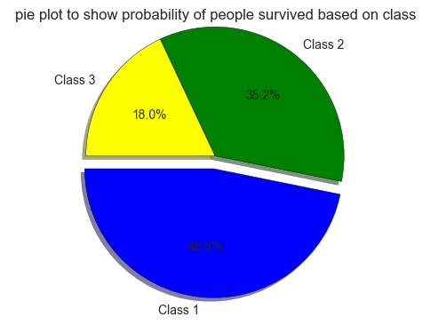

```python
# the data to be send to the function
# first we'll  demonstrate the pie plot for Passenger Class
values = statistic_class['probability_saved']
explode = (0.1,0,0)
labels = 'Class 1','Class 2','Class 3'
colors = ('blue','green','yellow')

title('pie plot to show probability of people survived based on class')
pie_plot(values,explode,labels,colors)
```

Here, we notice that class 1 has the most probability to be saved. Let's discuss why it happened !!! But this is what we expected ,didn't we?

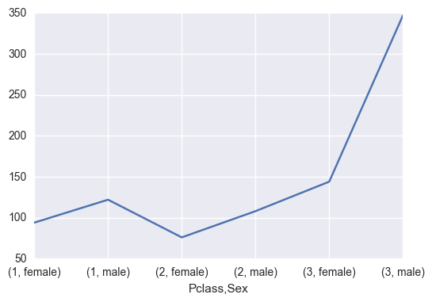

```python
#relation of class with gender
class_gender = titanic_data.groupby(['Pclass','Sex']).size()
class_gender.plot()
```

Here we see, class 3 has the highest number of males and the probability of males is less to survive , this may have been the reason that class 3 has the least probability of survival . Class 1 has more proportion of female so it has the highest survival probability.

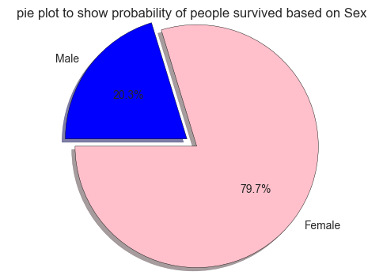

```python
# the data to be send to the function
# now we'll demonstratethe  pie plot forprobability of people saved based on Sex
values = statistic_gender['probability_saved']
explode = (0.1,0)
labels = 'Female','Male'
colors = ('pink','blue')

title('pie plot to show probability of people survived based on Sex')
pie_plot(values,explode,labels,colors)
```

[figure not shown]

```python
# the data to be send to the function
# now we'll demonstrate the pie plot for probability based on Embarked Station
values = statistic_class['probability_saved']
explode = (0.1,0,0)
labels = 'C','Q','S'
colors = ('violet','orange','yellow')

title('pie plot to show probability of people survived based on Embarked Station')
pie_plot(values,explode,labels,colors)
```

In this pie plot we notice that people who boarded from station 'C' had more chance of survival. Strange ! but this is the beauty of data analysis ...isn't it? But the interesting part is , the beauty doesn't lie there instead in the fact that we have the power to know why it happened. The below anlaysis will be for the same.

```
Pclass  Embarked
1       C            85
        Q             2
        S           127
2       C            17
        Q             3
        S           164
3       C            66
        Q            72
        S           353
dtype: int64
```

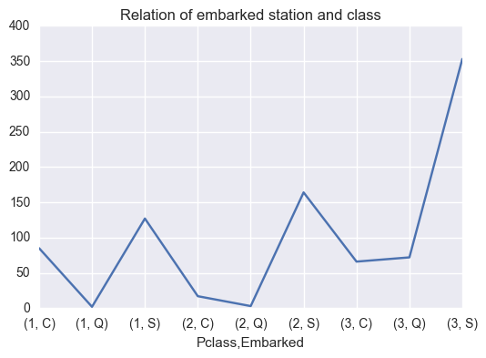

```python
embark_class = titanic_data.groupby(['Pclass','Embarked']).size()
print embark_class
title("Relation of embarked station and class")
embark_class.plot()
```

```python
a = pd.cut(titanic_data['Age'],8)
a = pd.crosstab(a,'Number')
a
```

| col_0 Age | Number |
| --- | --- |
| (0.34, 10.367] | 64 |
| (10.367, 20.315] | 115 |
| (20.315, 30.263] | 230 |
| (30.263, 40.21] | 155 |
| (40.21, 50.157] | 86 |
| (50.157, 60.105] | 42 |
| (60.105, 70.0525] | 17 |
| (70.0525, 80] | 5 |

Conclusion: 1)Female have more probability to be saved 2)P1 class has the highest probability to be saved Moreover Correlation does not imply causation should be taken into consideration. The results and conclusion has the chance to differ when the whole population is taken into consideration.

# Limitations

There were about more than 2200 people on the board and the sample has only 891 passengers so the dataset may contain a particular data more. The dataset didn't have any crew member details, which I felt was the most important as they had the least chances of survival keeping the service ethics into consideration.

# Reference Links

http://pandas.pydata.org/pandas-docs/version/0.15.0/visualization.html#pie-plot

http://pandas.pydata.org/pandas-docs/version/0.18.1/visualization.html#pie-plot

https://plot.ly/python/pie-charts/

http://stackoverflow.com/questions/10970696/draw-pie-chartusing-matplotlib-in-python

https://pythonspot.com/en/matplotlib-pie-chart/

http://matplotlib.org/1.2.1/examples/pylab_examples/pie_demo.html

https://www.analyticsvidhya.com/blog/2015/05/data-visualization-python/